# Crecimiento y Desarrollo Económico

## Dinámicas de difusión

La tasa de crecimiento de la difusión es por tanto
$$g_D = \psi h \left(\frac{A_t}{D_t}\right)^{\gamma}.$$

- La razón $A/D$ dicta el ritmo de crecimiento de variedades
- Similar a modelos anteriores donde la razón de stocks dicta una tasa de crecimiento
- Nota que mientras $D$ sube, $g_D$ baja, similar a las dinámicas de Solow/Romer

## Dinámicas de difusión

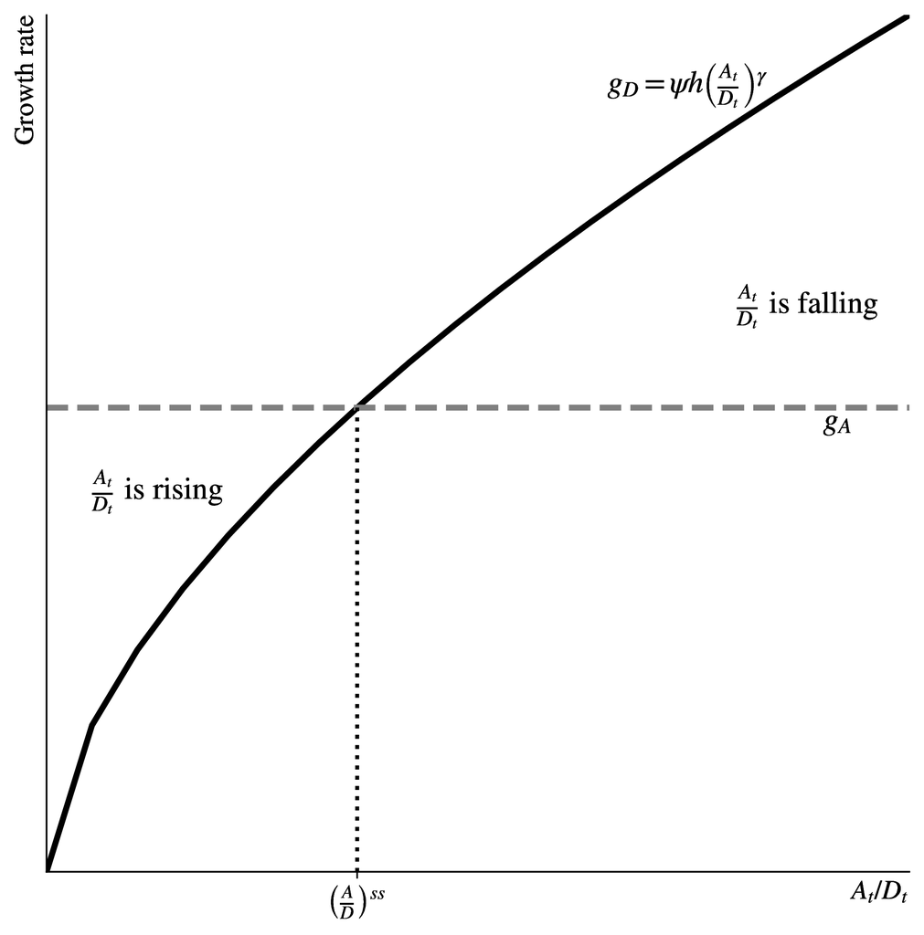

## Equilibrio de Estado Estacionario

Dada cualquier razón inicial $A/D$

- La tasa de crecimiento $g_D = g_A$
- Los seguidores solo pueden crecer tan rápido como los líderes
- Mientras alcanzan se desaceleran
- El nivel de $D$ determina qué tan cerca de la frontera está un país

## Equilibrio de Estado Estacionario

¿Cuál es la razón $A/D$ de estado estacionario?
$$\left(\frac{A}{D}\right)^{ss} = \left(\frac{g_A}{\psi h}\right)^{1/\gamma}.$$
Esta razón es *menor* y el seguidor está *más cerca* cuando

- $h$ es alto. Más CH significa más fácil adoptar nuevas tecnologías
- $g_A$ es bajo. Si el líder crece lentamente, es más fácil mantener el paso

## Senda de Crecimiento Balanceado (SCB)

En cualquier momento dado el nivel de $D_t$ es
$$D_t = \left(\frac{\psi h}{g_A}\right)^{1/\gamma} A_t,$$
lo que significa que la SCB para PIB per cápita en el seguidor es
$$y_t^{SCB} = \left(\frac{s_I}{g_A + g_L + \delta} \right)^{\frac{\alpha}{1-\alpha}} h \left(\frac{\psi h}{g_A}\right)^{1/\gamma} A_t.$$
y el seguidor corre “paralelo” a la SCB del líder.

## Capital Humano

Nota que con esta SCB
$$y_t^{SCB} = \left(\frac{s_I}{g_A + g_L + \delta} \right)^{\frac{\alpha}{1-\alpha}} h \left(\frac{\psi h}{g_A}\right)^{1/\gamma} A_t.$$

- El capital humano es más importante que solo vía habilidades ($h$)
- El término $h^{1/\gamma}$ influye en la difusión
- La contabilidad del desarrollo puede subestimar la importancia del capital humano

# Comercio y Globalización

## Importando ideas

Piensa en el comercio internacional como una forma de importar ideas vía variedades.
$$Y_t = (h_t L_t)^{1-\alpha} \int_0^{D_t+M_t} x_{jt} dj.$$
donde $D_t$ son las variedades domésticas y $M_t$ son variedades importadas. El comercio puede elevar el PIB agregando nuevos tipos de bienes.

## Producción doméstica

En el lado doméstico,
$$D_tz_t = K_t.$$
El país usa $K_t$ en capital para producir $z_t$ unidades de las $D_t$ variedades que puede hacer.
$$K_t - D_tx_t = D_t (z_t - x_t) = M_tx_t.$$
Pero el país solo *usa* $x_t$ unidades de esas variedades, dejando $D_t(z_t-x_t)$ para exportación, que se intercambian por $M_t x_t$ unidades de variedades extranjeras.

## Balanza comercial

Interpretando el comercio:

- Puedes pensar en $D_t (z_t - x_t)$ como una cantidad literal de bienes enviados a países extranjeros.
- Puedes pensar en $M_t x_t$ como la cantidad de bienes importados de esos países
- O puedes pensar en $D_t (z_t - x_t)$ como capital que es propiedad del país doméstico en un país extranjero (IED saliente)
- y entonces $M_tx_t$ es la cantidad de capital propiedad de un país extranjero en el país doméstico (IED entrante)

Esto asume comercio equilibrado todo el tiempo. Agregar déficits o superávits involucra trabajo adicional en el lado del consumo.

## Comercio y PIB

Cualesquiera que sean las interpretaciones tenemos
$$K_t = x_t(D_t + M_t),$$
lo que nos permite escribir el PIB como
$$Y_t = K_t^{\alpha}(D_th_tL_t)^{1-\alpha}\left(1+\frac{M_t}{D_t}\right)^{1-\alpha}.$$
Las variedades domésticas actúan como un término de productividad. Pero también tenemos esta razón $M_t/D_t$ que puede impulsar la productividad. Nota que
$$\frac{\text{Importaciones}}{\text{PIB}} = \frac{M_tx_t}{Y_t} = \frac{M_t}{D_t+M_t}\frac{K_t}{Y_t}$$
entonces si importaciones/PIB suben, el PIB debería ser mayor. El comercio es inequívocamente bueno para el PIB en esta configuración debido a las variedades.

## Comercio y PIB

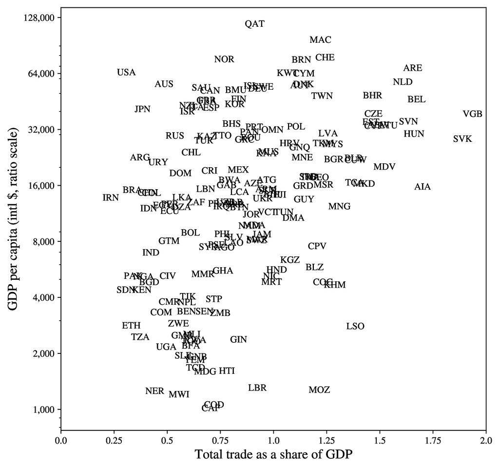